# 02_Model Selection in Bayesian Linear Regression

## 1. Where we left off

In the previous lecture we modelled tooth length in guinea pigs as a function of the vitamin C dose and the supplement type. We considered two specifications: an additive model

$$y_i = \beta_0+ \beta_1 \, \text{dose}_i + \beta_2 \, z_i +
\varepsilon_i,$$

and a model with interaction between dose and supplement type,

$$y_i = \beta_0+ \beta_1 \, \text{dose}_i + \beta_2 \, z_i + \beta_3 \,
\text{dose}_i \cdot z_i + \varepsilon_i,$$

where $z_i$ is the dummy associated with `supp`. Visually the two fits looked different, but we noticed that we cannot simply compare them via their fit on the data itself: the second model nests the first, so it will always fit at least as well. We need a criterion that **trades off goodness-of-fit and model complexity**.

This is exactly the topic of model selection. In this lecture we will:

- introduce the **Bayes Factor** and apply it to the two `ToothGrowth` specifications;
- generalise to settings with many candidate predictors, where the number of candidate models is $2^p$, using the **Bayesian Information Criterion (BIC)**;
- average across models via **Bayesian Model Averaging (BMA)**, instead of selecting a single one;
- briefly discuss the **Jeffreys-Zellner-Siow (JZS)** prior.

We start by reloading the libraries and data we need.

```r
# Clear the workspace
rm(list=ls())

set.seed(123)

library("ggplot2")
library("BAS")
library("latex2exp")

# Reload the dataset from the previous lecture
data(ToothGrowth)
n = nrow(ToothGrowth)
```

## 2. Comparing two models: the Bayes Factor

Suppose we have two competing models $M_1$ and $M_2$ for the same data $\mathbf{y}$. From a Bayesian perspective, each model has a *marginal likelihood* (or *evidence*)

$$p\left(\mathbf{y}\mid M_k\right) = \int p\left(\mathbf{y}\mid \theta_k,
M_k\right) \, \pi\left(\theta_k \mid M_k\right) \, d\theta_k,
\qquad k=1,2,$$

which is the likelihood of the data averaged over the prior on the parameters $\theta_k$ of model $M_k$. Notice that $p\left(\mathbf{y}\mid M_k\right)$ does *not* depend on the parameters: it only depends on the model specification and on the prior.

The **Bayes Factor** of $M_1$ against $M_2$ is the ratio of their marginal likelihoods,

$$BF[M_1:M_2]=\frac{p\left(\mathbf{y}\mid
M_1\right)}{p\left(\mathbf{y}\mid M_2\right)}.$$

Using Bayes’ rule on models, one easily checks that

$$\underbrace{\frac{p\left(M_1\mid \mathbf{y}\right)}{p\left(M_2\mid
\mathbf{y}\right)}}_{\text{posterior odds}}
\;=\;
\underbrace{\frac{p\left(\mathbf{y}\mid
M_1\right)}{p\left(\mathbf{y}\mid M_2\right)}}_{BF[M_1:M_2]}
\;\times\;
\underbrace{\frac{p(M_1)}{p(M_2)}}_{\text{prior odds}}.$$

In words, the Bayes Factor is the multiplicative factor that updates the prior odds into the posterior odds. If we put equal prior probability on the two models, $p(M_1)=p(M_2)$, then $BF[M_1:M_2]$ coincides with the posterior odds.

Why does the Bayes Factor automatically penalize complexity? The marginal likelihood spreads prior mass over the entire parameter space: a more complex model has a larger parameter space, so the prior is more diffuse and the marginal likelihood is typically smaller, *unless* the extra flexibility is supported by the data. This phenomenon is sometimes called **Bayesian Occam’s razor**.

A common interpretation scale is the one proposed by Jeffreys:

| $BF[M_1:M_2]$ | Evidence in favour of $M_1$ |
| --- | --- |
| $1 - 3$ | Not worth more than a bare mention |
| $3 - 10$ | Substantial |
| $10 - 30$ | Strong |
| $30 - 100$ | Very strong |
| $> 100$ | Decisive |

Values below $1$ are read symmetrically by inverting the ratio (i.e. evidence in favour of $M_2$).

### Computing the Bayes Factor with `BAS`

The function `bas.lm` makes the computation straightforward: when we specify a formula with several terms, by default it enumerates all submodels and reports their marginal likelihoods together with the Bayes Factor against the model with highest posterior probability.

We compare the two `ToothGrowth` specifications by fitting the full interaction model: this expands to three terms (`dose`, `suppVC`, `dose:suppVC`), so `bas.lm` considers all $2^3=8$ submodels.

```r
# We use Zellner's g-prior with g = n (a unit information prior)
tooth.bas = bas.lm(len ~ dose * supp,
                   data = ToothGrowth,
                   prior = "g-prior", alpha = n,
                   modelprior = uniform())

round(summary(tooth.bas), 3)
```

```
##             P(B != 0 | Y) model 1 model 2 model 3 model 4 model 5
## Intercept           1.000   1.000   1.000   1.000   1.000   1.000
## dose                1.000   1.000   1.000   1.000   1.000   0.000
## suppVC              0.972   1.000   1.000   0.000   0.000   1.000
## dose:suppVC         0.611   1.000   0.000   0.000   1.000   1.000
## BF                     NA   1.000   0.619   0.028   0.018   0.000
## PostProbs              NA   0.600   0.372   0.017   0.011   0.000
## R2                     NA   0.730   0.704   0.644   0.664   0.523
## dim                    NA   4.000   3.000   2.000   3.000   3.000
## logmarg                NA  31.134  30.655  27.576  27.102  17.221
```

Some comments on the output:

- The first three rows under `P(B!=0 | Y)` are the **posterior inclusion probabilities** of each term, i.e. $P(\beta_j\neq 0\mid \mathbf{y})$;
- Each subsequent column is a model: a value of $1$ or $0$ tells us whether the term is included;
- `BF` is the Bayes Factor against the model with the largest posterior probability (so the top model has $BF=1$ by construction);
- `PostProbs` are the model posterior probabilities $p(M_m\mid \mathbf{y})$;
- `dim` is the number of regressors in the model, including the intercept;
- `logmarg` is the log marginal likelihood $\ln p(\mathbf{y}\mid M_m)$.

Let’s read it. The model with highest posterior probability is the interaction one (`dose + supp + does:supp`). The additive model (all three flags equal to $1$ except for the interaction) is the runner-up. To get the Bayes Factor of the additive model versus the interaction model, we compute

```r
# Posterior probabilities indexed by model
pp = tooth.bas$postprobs
which_models = sapply(tooth.bas$which, paste, collapse=",")
data.frame(model = which_models, PostProb = round(pp, 3))
```

```
##     model PostProb
## 1       0    0.000
## 2   0,1,3    0.011
## 3     0,3    0.000
## 4     0,1    0.017
## 5 0,1,2,3    0.600
## 6   0,2,3    0.000
## 7     0,2    0.000
## 8   0,1,2    0.372
```

`bas.lm` numbers the variables starting from $0$ (the intercept), so `0,1,2` is the additive model (intercept + `dose` + `supp`) and `0,1,2,3` is the interaction model. The Bayes Factor is

```r
# Indices of the additive and interaction models
idx_add = which(which_models == "0,1,2")
idx_int = which(which_models == "0,1,2,3")

# Bayes Factor: additive vs interaction
BF_add_vs_int = exp(tooth.bas$logmarg[idx_add] - tooth.bas$logmarg[idx_int])
BF_add_vs_int
```

```
## [1] 0.6193947
```

And similarly:

```r
# Bayes Factor: additive vs interaction
BF_int_vs_add = exp(tooth.bas$logmarg[idx_int] - tooth.bas$logmarg[idx_add])

BF_int_vs_add
```

```
## [1] 1.614479
```

The Bayes Factor of the additive model against the interaction one is roughly 0.62. On Jeffreys’ scale this would be considered not worth mentioning evidence in favour of the more complex model.

A useful sanity check is that $BF$ together with the prior odds reconstructs the posterior odds:

```r
# Posterior odds: additive vs interaction
pp[idx_add] / pp[idx_int]
```

```
## [1] 0.6193947
```

which equals the Bayes Factor when, as in this example, the prior over models is uniform.

### A sanity check

We fit the additive model by ordinary least squares to obtain coefficient estimates and a residual standard deviation, then generate new responses from this model while keeping the original design matrix:

```r
# Fit the additive model and treat it as the data-generating process
tooth.add = lm(len ~ dose + supp, data = ToothGrowth)
sigma_hat = summary(tooth.add)$sigma

# Simulate a new response, keeping the original `dose` and `supp` columns
set.seed(1997)
ToothSim = ToothGrowth
ToothSim$len = predict(tooth.add) + rnorm(nrow(ToothSim), 0, sigma_hat)
```

We repeat the BAS analysis on the simulated data, using the same `dose * supp` formula so that all 8 submodels are again enumerated:

```r
sim.bas = bas.lm(len ~ dose * supp,
                 data = ToothSim,
                 prior = "g-prior", alpha = n,
                 modelprior = uniform())

round(summary(sim.bas), 3)
```

```
##             P(B != 0 | Y) model 1 model 2 model 3 model 4 model 5
## Intercept           1.000   1.000   1.000   1.000   1.000   1.000
## dose                1.000   1.000   1.000   1.000   1.000   0.000
## suppVC              0.940   1.000   1.000   0.000   0.000   1.000
## dose:suppVC         0.176   0.000   1.000   1.000   0.000   1.000
## BF                     NA   1.000   0.140   0.073   0.000   0.000
## PostProbs              NA   0.824   0.115   0.060   0.000   0.000
## R2                     NA   0.756   0.757   0.732   0.606   0.432
## dim                    NA   3.000   4.000   3.000   2.000   3.000
## logmarg                NA  36.051  34.084  33.436  24.698  12.193
```

And extract the Bayes Factor of the additive model against the interaction one:

```r
which_sim = sapply(sim.bas$which, paste, collapse = ",")
idx_add_sim = which(which_sim == "0,1,2")
idx_int_sim = which(which_sim == "0,1,2,3")

BF_add_vs_int_sim = exp(sim.bas$logmarg[idx_add_sim] - sim.bas$logmarg[idx_int_sim])
BF_add_vs_int_sim
```

```
## [1] 7.149441
```

The Bayes Factor now favours the additive model — appropriately so, since by construction there is no interaction in the simulated data (even though, the interaction model is more general, so Bayes Theorem is correcting for the additional complexity and penalizing more complex models). Compared to the real `ToothGrowth` analysis the picture is much sharper: with the extra term genuinely absent, the marginal likelihood of the simpler model wins out and the complexity penalty does its job. As a further check, you may repeat the simulation under different seeds to see how stable the conclusion is, or simulate from the *interaction* model (using `lm(len ~ dose * supp, data = ToothGrowth)` as the data-generating process) and verify that the Bayes Factor flips direction.

## 3. Many candidate models: BIC

When the number of predictors $p$ is moderately large, comparing models pairwise becomes impractical: we have $2^p$ candidate models, each with its own posterior probability. A more practical question becomes “which variables matter?”.

A widely used approximation for the marginal likelihood is the **Bayesian Information Criterion**,

$$BIC = -2\ln p\left(\mathbf{y}\mid \widehat{\beta}, \widehat{\sigma}^2,
M\right) + (p+1)\ln(n),$$

where $\widehat{\beta},\widehat{\sigma}^2$ are the maximum likelihood estimates, $p$ is the number of regressors excluding the intercept, and $n$ is the sample size. For data from the exponential family and as $n\to\infty$,

$$BIC \approx -2\ln p(\mathbf{y}\mid M),$$

so the BIC is essentially $-2$ times the log marginal likelihood. It follows that the Bayes Factor between two models can be approximated as

$$BF[M_1:M_2] \approx \exp\left\{-\tfrac{1}{2}\left(BIC_1 -
BIC_2\right)\right\},$$

which is convenient because BIC requires only the maximum of the likelihood, not an explicit prior on the parameters.

**A word of warning.** The BIC is *not* a prior. In `bas.lm` the choice `prior = "BIC"` corresponds to a non-informative reference prior on the coefficients, whose marginal likelihood is approximated by the BIC. The Zellner $g$-prior, the JZS prior and the BIC-based approximation are *different priors*, and each induces a different marginal likelihood. They will all give qualitatively similar answers in most applications, but quantitatively distinct posterior model probabilities.

### Application: predicting fuel efficiency

In Exercise 1 of the previous lecture we fitted a simple linear regression of `mpg` on `hp` using the `mtcars` dataset. We now go beyond a single predictor and ask: among the many automobile features available, which ones really help to predict fuel efficiency?

To keep the exposition compact we focus on four predictors:

- `hp`: gross horsepower (continuous);
- `wt`: weight in 1000 lbs (continuous);
- `qsec`: 1/4 mile time in seconds (continuous);
- `am`: transmission, $0$=automatic, $1$=manual (binary).

This gives $2^4=16$ candidate models.

```r
data(mtcars)

# Restrict to the variables of interest and ensure `am` is a 0/1 indicator
cars = mtcars[, c("mpg","hp","wt","qsec","am")]
str(cars)
```

```
## 'data.frame':    32 obs. of  5 variables:
##  $ mpg : num  21 21 22.8 21.4 18.7 18.1 14.3 24.4 22.8 19.2 ...
##  $ hp  : num  110 110 93 110 175 105 245 62 95 123 ...
##  $ wt  : num  2.62 2.88 2.32 3.21 3.44 ...
##  $ qsec: num  16.5 17 18.6 19.4 17 ...
##  $ am  : num  1 1 1 0 0 0 0 0 0 0 ...
```

We run `bas.lm` with `prior = "BIC"` and a uniform prior over models, $p(M_m)=1/16$ for $m=1,\ldots,16$.

```r
cars.BIC = bas.lm(mpg ~ ., data = cars,
                  prior = "BIC", modelprior = uniform())

round(summary(cars.BIC), 3)
```

```
##           P(B != 0 | Y) model 1 model 2 model 3 model 4 model 5
## Intercept         1.000   1.000   1.000   1.000   1.000   1.000
## hp                0.507   0.000   1.000   0.000   1.000   1.000
## wt                0.994   1.000   1.000   1.000   1.000   1.000
## qsec              0.694   1.000   0.000   1.000   1.000   0.000
## am                0.568   1.000   0.000   0.000   1.000   1.000
## BF                   NA   1.000   0.586   0.567   0.433   0.365
## PostProbs            NA   0.312   0.183   0.177   0.135   0.114
## R2                   NA   0.850   0.827   0.826   0.858   0.840
## dim                  NA   4.000   3.000   3.000   5.000   4.000
## logmarg              NA -89.037 -89.571 -89.605 -89.874 -90.045
```

Reading the table:

- The top model is the one with highest posterior probability;
- `P(B!=0 | Y)` gives the marginal posterior inclusion probability of each variable, computed by summing the posterior probabilities of all models that include it;
- `BF` is the Bayes Factor against the top model.

We can extract the **highest posterior model (HPM)** explicitly:

```r
# Index of the model with largest log marginal likelihood
cars.best = which.max(cars.BIC$logmarg)

# Variables included (index 0 is the intercept)
selectedVars = cars.BIC$which[[cars.best]] + 1
cars.BIC$namesx[selectedVars]
```

```
## [1] "Intercept" "wt"        "qsec"      "am"
```

A very informative visualization is the **model rank plot**, which displays which variables are included across the top models, ranked by posterior probability.

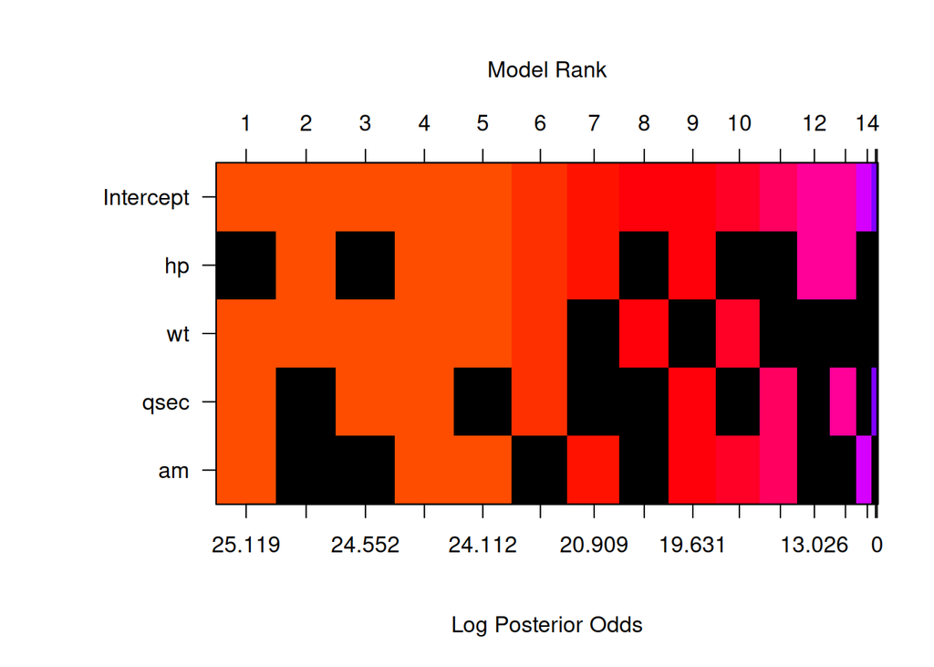

```r
image(cars.BIC, rotate = FALSE)
```

On the $x$-axis the models are ranked by log posterior odds against the benchmark (because the prior over models is uniform, this is the same as the log Bayes Factor). On the $y$-axis the variables are listed; coloured cells indicate inclusion in that model. A row that is uniformly coloured across the top models suggests that the corresponding variable is consistently selected; a row with a mixed pattern suggests genuine uncertainty about whether to include that variable.

## 4. Bayesian Model Averaging

So far we have asked “which is the best model?” and tried to pick one. But picking a single model means ignoring the uncertainty about which model is correct. A more honest approach is to **average across models**, weighting them by their posterior probability.

For any quantity of interest $\theta$ (a coefficient, a prediction, a function of the parameters),

$$p\left(\theta\mid \mathbf{y}\right) = \sum_{j=1}^{2^p} p\left(\theta\mid
\mathbf{y}, M_j\right) \, p\left(M_j\mid \mathbf{y}\right).$$

This is the **Bayesian Model Averaging (BMA)** distribution of $\theta$. In particular, the BMA prediction at a new design point $x^\ast$ is

$$\widehat{y}^{\,\ast} = \sum_{j=1}^{2^p} \widehat{y}_j^{\,\ast} \,
p\left(M_j\mid \mathbf{y}\right),$$

a weighted average of the predictions made under each model, with weights given by the posterior model probabilities. Models that fit poorly receive a small weight and contribute little; models that fit comparably well share the load.

Two consequences worth highlighting:

- **Predictive intervals are wider** than under any single model, because they incorporate model uncertainty in addition to parameter uncertainty;
- **Posterior inclusion probabilities** $P(\beta_j\neq 0\mid \mathbf{y}) = \sum_{j: \beta_j\in M_j} p(M_j\mid \mathbf{y})$ provide a model-averaged measure of how relevant each predictor is, often more useful than a yes/no decision based on a single model.

By default `bas.lm` returns the BMA estimator. We extract it and the associated credible intervals:

```r
# Coefficients under BMA
cars.coef = coef(cars.BIC, estimator = "BMA")
cars.coef
```

```
##
##  Marginal Posterior Summaries of Coefficients:
##
##  Using  BMA
##
##  Based on the top  16 models
##            post mean  post SD   post p(B != 0)
## Intercept  20.09062    0.44691   1.00000
## hp         -0.01403    0.01731   0.50687
## wt         -3.91273    1.01884   0.99406
## qsec        0.69230    0.57240   0.69428
## am          1.58130    1.76839   0.56773
```

The column `post mean` is the BMA posterior mean of each coefficient, computed across all 16 models. The column `post SD` accounts for both within-model and between-model variability.

We can plot the marginal posterior of each coefficient under BMA. These distributions are *mixtures*: they have a point mass at zero (corresponding to models that exclude the variable) and a continuous part (from models that include it).

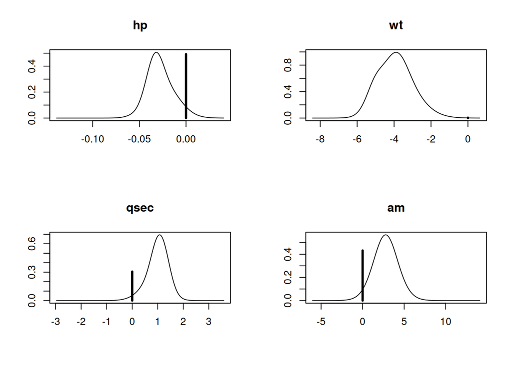

```r
par(mfrow = c(2,2))
plot(cars.coef, subset = 2:5, ask = FALSE)
```

The height of the spike at zero is exactly $1 - P(\beta_j\neq 0\mid \mathbf{y})$, i.e. the posterior probability that the variable is excluded. Variables with large spikes (e.g. `hp` in our case) are uncertain, while variables with small spikes (e.g. `wt`) are consistently selected.

We can also extract credible intervals that fully account for model uncertainty:

```r
cars.confint = confint(cars.coef)
cars.confint[, 1:3]
```

```
##                  2.5%         97.5%        beta
## Intercept 19.16491257  2.100393e+01 20.09062500
## hp        -0.04985577  1.539936e-05 -0.01403343
## wt        -5.88442945 -1.936343e+00 -3.91272835
## qsec       0.00000000  1.619323e+00  0.69230238
## am         0.00000000  5.213726e+00  1.58129583
```

Notice that some of these intervals contain $0$: this should not be read mechanically as “the variable is not relevant”, because the asymmetric mass at zero already encodes the inclusion probability. The intervals are honest reflections of all sources of uncertainty.

### BMA for prediction

Let us compare the BMA prediction to the prediction under the highest posterior model only. We predict `mpg` for the cars in the dataset and inspect the predictive uncertainty.

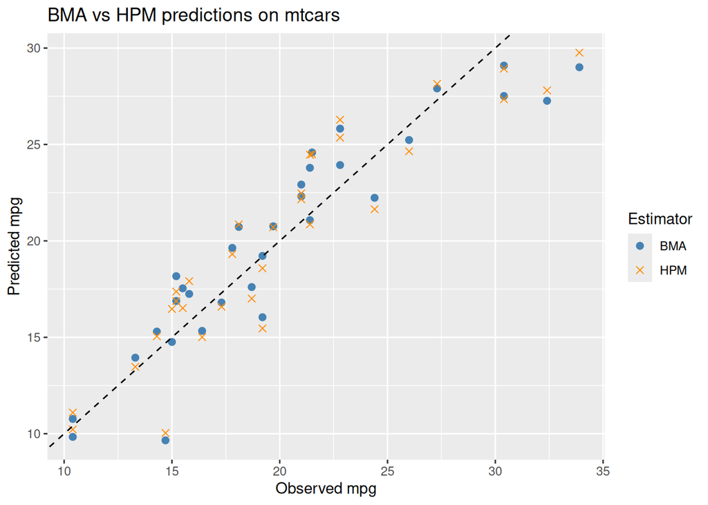

```r
# Predictions under BMA and under HPM
pred.bma = predict(cars.BIC, estimator = "BMA", se.fit = TRUE)
pred.hpm = predict(cars.BIC, estimator = "HPM", se.fit = TRUE)

# Build a data frame for plotting
pred_df = data.frame(
  observed = cars$mpg,
  bma = as.numeric(pred.bma$fit),
  hpm = as.numeric(pred.hpm$fit)
)

ggplot(pred_df) +
  geom_point(aes(x = observed, y = bma, color = "BMA"), size = 2) +
  geom_point(aes(x = observed, y = hpm, color = "HPM"), size = 2, shape = 4) +
  geom_abline(intercept = 0, slope = 1, linetype = "dashed") +
  scale_color_manual(name = "Estimator",
                     values = c("BMA" = "steelblue", "HPM" = "darkorange")) +
  xlab("Observed mpg") + ylab("Predicted mpg") +
  ggtitle("BMA vs HPM predictions on mtcars")
```

The two estimators give similar point predictions in this example, but the BMA point predictions are slightly shrunk towards each other compared to HPM, because they average across simpler and more complex specifications.

### Mean response and predictive intervals under BMA

The point predictions above hide an important distinction. For any new covariate vector $x^\ast$, two different interval questions can be asked:

- a **95% credible interval for the mean response** $E(y^\ast\mid x^\ast, \mathbf{y})$, capturing uncertainty about $\beta$ and about the model;
- a **95% posterior predictive interval** for a new observation $y^\ast \mid x^\ast$, which additionally includes the irreducible noise $\sigma^2$.

The predictive interval is always at least as wide as the mean-response interval, and it is the relevant object when the goal is to communicate uncertainty about individual outcomes rather than about the regression function.

Both are recovered from the same prediction object via `confint()`, by selecting `parm = "mean"` or `parm = "pred"`. We compute them at the observed covariates and overlay them on the BMA fit:

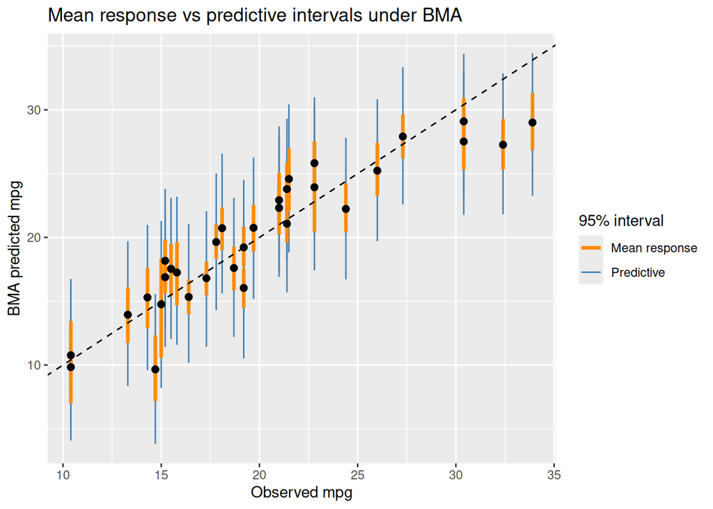

```r
# Predictions with standard errors
pred.bma = predict(cars.BIC, estimator = "BMA", se.fit = TRUE)

# 95% credible interval for the mean response E[y | x]
ci.mean = confint(pred.bma, parm = "mean")

# 95% posterior predictive interval for a future observation at x
ci.pred = confint(pred.bma, parm = "pred")

# Combine for plotting
pred_df = data.frame(
  observed = cars$mpg,
  fit      = as.numeric(pred.bma$fit),
  mean_lwr = ci.mean[, 1], mean_upr = ci.mean[, 2],
  pred_lwr = ci.pred[, 1], pred_upr = ci.pred[, 2]
)

ggplot(pred_df, aes(x = observed, y = fit)) +
  geom_errorbar(aes(ymin = pred_lwr, ymax = pred_upr, color = "Predictive"),
                width = 0) +
  geom_errorbar(aes(ymin = mean_lwr, ymax = mean_upr, color = "Mean response"),
                width = 0, linewidth = 1.2) +
  geom_point(size = 2) +
  geom_abline(intercept = 0, slope = 1, linetype = "dashed") +
  scale_color_manual(name = "95% interval",
                     values = c("Mean response" = "darkorange",
                                "Predictive"    = "steelblue")) +
  xlab("Observed mpg") + ylab("BMA predicted mpg") +
  ggtitle("Mean response vs predictive intervals under BMA")
```

Two takeaways:

- The orange (mean-response) bars are visibly shorter than the blue (predictive) ones. With only $n=32$ observations and four candidate predictors, parameter and model uncertainty are not trivial — but the irreducible noise $\sigma^2$ still dominates the width of the predictive interval.
- All observed values fall inside the predictive bands, as one would hope; some fall outside the mean-response bands, which is exactly what should happen, since those bands describe $E(y\mid x)$ and not individual outcomes.

This is the same distinction familiar from the frequentist linear model between *confidence* and *prediction* bands, with the additional twist that under BMA both bands also absorb model uncertainty: the mean-response band, in particular, is wider than the corresponding `lm()` confidence band would be, because it combines uncertainty about $\beta$ *and* about which model is correct.

## 5. A note on the choice of prior

We have now seen three priors for the regression coefficients in a Bayesian linear model:

- the **non-informative reference prior** of Section 3 of the previous lecture, which gives credible intervals numerically equal to OLS confidence intervals;
- **Zellner’s** $g$-prior, $\beta\mid\sigma^2 \sim \mathscr{N}\left(\mathbf{0},\, g\,\sigma^2(X'X)^{-1}\right)$, which requires us to choose the hyperparameter $g$;
- the **BIC-based approximation**, which uses the reference prior and approximates the marginal likelihood via the BIC.

Each of these choices leads to a slightly different marginal likelihood and therefore to slightly different posterior model probabilities. A fourth and very popular choice avoids fixing $g$ subjectively by placing a prior on it:

$$\begin{aligned}
\beta_j\mid \sigma^2, g &\sim \mathscr{N}\left(0,
g\,\sigma^2(X'X)^{-1}\right), \\
g &\sim \mathscr{IG}\left(\tfrac{1}{2}, \tfrac{n}{2}\right), \\
p(\sigma^2) &\propto \sigma^{-2}.
\end{aligned}$$

Marginalising over $g$ produces a Cauchy prior on $\beta_j\mid \sigma^2$, the so-called **Jeffreys-Zellner-Siow (JZS)** prior. It has heavier tails than any single $g$-prior and is invariant under rescaling of the regressors. The marginal likelihood is no longer available in closed form, but `bas.lm` provides it via numerical integration.

We rerun the `mtcars` analysis with the JZS prior to see whether the conclusions change qualitatively:

```r
cars.JZS = bas.lm(mpg ~ ., data = cars,
                  prior = "JZS", modelprior = uniform())

round(summary(cars.JZS), 3)
```

```
##           P(B != 0 | Y) model 1 model 2 model 3 model 4 model 5
## Intercept         1.000   1.000   1.000   1.000   1.000   1.000
## hp                0.501   1.000   0.000   0.000   1.000   1.000
## wt                0.987   1.000   1.000   1.000   1.000   1.000
## qsec              0.612   0.000   1.000   1.000   0.000   1.000
## am                0.402   0.000   0.000   1.000   1.000   1.000
## BF                   NA   1.000   0.971   0.857   0.365   0.249
## PostProbs            NA   0.264   0.256   0.226   0.096   0.066
## R2                   NA   0.827   0.826   0.850   0.840   0.858
## dim                  NA   3.000   3.000   4.000   4.000   5.000
## logmarg              NA  21.219  21.189  21.065  20.211  19.830
```

The picture is essentially the same: `wt` is selected with very high probability, `qsec` follows, and `hp` and `am` carry low to moderate inclusion probabilities. The robustness of these conclusions across priors is a reassuring sign — when it does *not* hold, that is itself useful information that the data are not strongly informative on the question of variable inclusion.

## Exercise 3: continuing with the `swiss` dataset

In Exercise 2 of the previous lecture you fitted two competing specifications on the `swiss` dataset:

- the additive model `Fertility ~ Education + Catholic`;
- the model with interaction `Fertility ~ Education * Catholic`.

You produced plots and gave an informal interpretation of the interaction term. We can now answer the question we postponed: *is the interaction supported by the data?*

1. Refit both models on `swiss` using `bas.lm` with `prior = "g-prior"` and `alpha = n`, where `n` is the sample size. Compute the Bayes Factor of the additive model against the interaction one, and interpret it on Jeffreys’ scale.
2. Now consider all the available predictors in the dataset (`Agriculture`, `Examination`, `Education`, `Catholic`, `Infant.Mortality`). Use `bas.lm` with `prior = "BIC"` and `modelprior = uniform()` to enumerate the $2^5=32$ candidate models for `Fertility`.
3. Identify the highest posterior model and compare its posterior probability to that of the runner-up. Compute the posterior inclusion probabilities of each variable.
4. Produce the `image()` plot of the model space and comment on which variables are consistently selected.
5. Compute the BMA posterior mean and 95% credible interval of each coefficient.
6. Compute the BMA posterior 95% credible interval for the mean response at the observed covariates.
7. Compute the BMA posterior predictive 95% interval for each prediction, compare it to the one computed at 6.

```r
# Load the dataset
data(swiss)

# write here your code
```